# Homework1

Aishwarya Saibewar

2023-04-05

```r
#Importing the required libraries
library(tidyverse)
library(ISLR2)
library(tree)
library(randomForest)
library(gbm)
library(dplyr)
library(tictoc)
```

# Loading the youth_data.Rdata file

```r
load("/Users/aishwaryasaibewar/Documents/SeattleUniversity-MSDS/Courses/SU Course Work/SPRING_2023/Statistical Machine Learning 2/Homework/Homework1/Dataset/youth_data.Rdata")
```

# Understanding the dataset

```r
#names(df)
#str(df)
#Youth Experience columns
youth_experience_cols
```

```
##  [1] "schfelt"  "tchgjob"  "avggrade" "stndscig" "stndsmj"  "stndalc"
##  [7] "stnddnk"  "parchkhw" "parhlphw" "PRCHORE2" "PRLMTTV2" "parlmtsn"
## [13] "PRGDJOB2" "PRPROUD2" "argupar"  "YOFIGHT2" "YOGRPFT2" "YOHGUN2"
## [19] "YOSELL2"  "YOSTOLE2" "YOATTAK2" "PRPKCIG2" "PRMJEVR2" "prmjmo"
## [25] "PRALDLY2" "YFLPKCG2" "YFLTMRJ2" "yflmjmo"  "YFLADLY2" "FRDPCIG2"
## [31] "FRDMEVR2" "frdmjmon" "FRDADLY2" "talkprob" "PRTALK3"  "PRBSOLV2"
## [37] "PREVIOL2" "PRVDRGO2" "GRPCNSL2" "PREGPGM2" "YTHACT2"  "DRPRVME3"
## [43] "ANYEDUC3" "rlgattd"  "rlgimpt"  "rlgdcsn"  "rlgfrnd"
```

```r
#Substance use columns
substance_cols
```

```
##  [1] "iralcfy"     "irmjfy"      "ircigfm"     "IRSMKLSS30N" "iralcfm"
##  [6] "irmjfm"      "ircigage"    "irsmklsstry" "iralcage"    "irmjage"
## [11] "mrjflag"     "alcflag"     "tobflag"     "alcydays"    "mrjydays"
## [16] "alcmdays"    "mrjmdays"    "cigmdays"    "smklsmdays"
```

```r
#Demographic columns
demographic_cols
```

```
##  [1] "irsex"      "NEWRACE2"   "HEALTH2"    "eduschlgo"  "EDUSCHGRD2"
##  [6] "eduskpcom"  "imother"    "ifather"    "income"     "govtprog"
## [11] "POVERTY3"   "PDEN10"     "COUTYP4"
```

#DATA CLEANING

*Create a new dataframe with required variables

#substance columns

#Demographics columns

- HEALTH2- overall health(Excellent / Very Good / Good / Fair or Poor)
- EDUSCHGRD2- what grade in now/will be in (11 categories, 98,99= blank/skip)
- irsex- gender (1=male, 2=female)

#Youth Experiences

- YOFIGHT2- youth had serious fight at school/work(one or more times/none)
- govtprog- got gov assistance (1=yes, 2=no)
- income- family income
- COUTYP4- metro size status (1=large metro, 2=small metro, 3=nonmetro)

```r
#creating new dataframe with selected variables
selected_data <-df %>%
  dplyr::select(alcflag,iralcfy,tobflag,mrjflag,alcydays,HEALTH2,EDUSCHGRD2,irsex,YOFIGHT2,govtprog,income,COUTYP4)
```

#Find the count of missing values in each column

```r
missing <- colSums(is.na(selected_data))
missing
```

```
##    alcflag    iralcfy    tobflag    mrjflag   alcydays    HEALTH2 EDUSCHGRD2
##          0          0          0          0          0          1          0
##      irsex   YOFIGHT2   govtprog     income    COUTYP4
##          0         23          0          0          0
```

#Impute the missing values of the categorical variable with the mode of the non-missing values.

*We have missing values in two columns HEALTH2 and YOFIGHT2.

```r
#For HEALTH2
a<-table(selected_data$HEALTH2)
```

```r
health_mode <- names(sort(a, decreasing = TRUE))[1]
```

```r
selected_data$HEALTH2[is.na(selected_data$HEALTH2)] <- health_mode
```

```r
#For YOFIGHT2
b<-table(selected_data$YOFIGHT2)
```

```r
fight_mode <- names(sort(b, decreasing = TRUE))[1]
```

```r
selected_data$YOFIGHT2[is.na(selected_data$YOFIGHT2)] <- fight_mode
```

#Manipulating iralcfy column

```r
#For Regression (4722 + 126 = 4848) records out of 5500 are
#991 = NEVER USED ALCOHOL
#993 = DID NOT USE ALCOHOL PAST YEAR

#As it represents the teen who have never consumed alcohol. Modify its values to int 0.

selected_data$iralcfy[selected_data$iralcfy %in% c(991, 993)] <- 0
```

#Manipulating alcflag column

```r
#Modify to Yes/No flag in alcflag
selected_data$alcflag <-  ifelse(selected_data$alcflag == 0, "No", "Yes")
```

#Manipulating tobflag column

```r
#Modify to Yes/No flag in tobflag
selected_data$tobflag <-  ifelse(selected_data$tobflag == 0, "No", "Yes")
```

#Manipulating mrjflag column

```r
#Modify to Yes/No flag in mrjflag
selected_data$mrjflag <-  ifelse(selected_data$mrjflag == 0, "No", "Yes")
```

#Manipulating alcydays column

```r
#Modify the categories to seldom, sometimes, never used and frequent, based on the number of days of alcohol consumption in a year
selected_data$alcydays <- ifelse(selected_data$alcydays == 6, "Never used", #6 = Non User or No Past Year Use
                          ifelse(selected_data$alcydays <= 2, "Seldom",     #1 = 1-11 Days
                                                                            #2 = 12-49 Days
                          ifelse(selected_data$alcydays == 3, "Sometimes",  #3 = 50-99 Days
                                 "Frequent")))                              #4 = 100-299 Days
                                                                            #5 = 300-365 Days
```

#Manipulating HEALTH2 column

```r
#levels of the HEALTH2
levels(selected_data$HEALTH2)
```

```
## [1] "1" "2" "3" "4"
```

```r
#Modify the categories to meaningful ones
selected_data$HEALTH2 <- factor(selected_data$HEALTH2, levels = c(1, 2 , 3 , 4), labels = c("Excellent", "Very Good", "Good", "Poor"))
```

#Manipulating EDUSCHGRD2 column

```r
#levels of the EDUSCHGRD2
levels(selected_data$EDUSCHGRD2)
```

```
##  [1] "1"  "2"  "3"  "4"  "5"  "6"  "7"  "8"  "9"  "10" "98" "99"
```

```r
#Modify the categories to meaningful ones
selected_data$EDUSCHGRD2 <- factor(selected_data$EDUSCHGRD2, levels = c("1" , "2" , "3" , "4" , "5" , "6" , "7" , "8" , "9" , "10", "98", "99"), labels = c("0-5", "6", "7", "8","9","10","11","12","College-1","College-2,3", "No answer", "Skip"))
```

```r
#levels of the EDUSCHGRD2
levels(selected_data$EDUSCHGRD2)
```

```
##  [1] "0-5"         "6"           "7"           "8"           "9"
##  [6] "10"          "11"          "12"          "College-1"   "College-2,3"
## [11] "No answer"   "Skip"
```

#Manipulating irsex column

```r
#Create meaningful values for irsex
selected_data$irsex <-  ifelse(selected_data$irsex == 1, "Male", "Female")
```

#Manipulating YOFIGHT2 column

```r
#levels of the YOFIGHT2
levels(selected_data$YOFIGHT2)
```

```
## [1] "1" "2"
```

```r
#Create meaningful values for YOFIGHT2
selected_data$YOFIGHT2 <-  ifelse(selected_data$YOFIGHT2 == 1, "Never", "1-2 times")
```

#Manipulating govtprog column

```r
#Create meaningful values for mrjflag
selected_data$govtprog <-  ifelse(selected_data$govtprog == 1, "Yes", "No")
```

#Modify income column

```r
#Create meaningful values for income
selected_data$income <- factor(selected_data$income, levels = c("1" , "2" , "3" , "4"), labels = c("< $20k", "$20k-$49,999", "$50k-$74,999", ">= $75k"))
```

```r
#levels of the income
levels(selected_data$income)
```

```
## [1] "< $20k"       "$20k-$49,999" "$50k-$74,999" ">= $75k"
```

#Manipulating COUTYP4 column

```r
# Check the levels of the COUTYP4
levels(selected_data$COUTYP4)
```

```
## [1] "1" "2" "3"
```

```r
#Create meaningful values for COUTYP4
selected_data$COUTYP4 <- factor(selected_data$COUTYP4, levels = c(1, 2 , 3), labels = c("Large Metro", "Small Metro", "Non Metro"))
```

```r
selected_data$COUTYP4 <- factor(selected_data$COUTYP4,level=c("Large Metro", "Small Metro", "Non Metro"))
```

#Change the datatype of variables

```r
#Change the datatype of variables to factors
selected_data$alcflag<- as.factor(selected_data$alcflag)
selected_data$iralcfy<-as.numeric(selected_data$iralcfy)
selected_data$tobflag<-as.factor(selected_data$tobflag)
selected_data$mrjflag<-as.factor(selected_data$mrjflag)
selected_data$alcydays<-as.factor(selected_data$alcydays)

selected_data$HEALTH2<- as.factor(selected_data$HEALTH2)
selected_data$EDUSCHGRD2<- as.factor(selected_data$EDUSCHGRD2)
selected_data$irsex<-as.factor(selected_data$irsex)

selected_data$YOFIGHT2<-as.factor(selected_data$YOFIGHT2)
selected_data$govtprog<-as.factor(selected_data$govtprog)
selected_data$income<- as.factor(selected_data$income)
selected_data$COUTYP4<-as.factor(selected_data$COUTYP4)
```

```r
#structure of selected_data
str(selected_data)
```

```
## 'data.frame':    5500 obs. of  12 variables:
##  $ alcflag   : Factor w/ 2 levels "No","Yes": 2 1 2 1 1 1 2 1 2 1 ...
##  $ iralcfy   : num  0 0 0 0 0 0 3 0 12 0 ...
##  $ tobflag   : Factor w/ 2 levels "No","Yes": 1 1 2 1 1 1 1 1 2 2 ...
##  $ mrjflag   : Factor w/ 2 levels "No","Yes": 1 1 2 1 1 1 1 1 1 2 ...
##  $ alcydays  : Factor w/ 4 levels "Frequent","Never used",..: 2 2 2 2 2 2 3 2 3 2 ...
##  $ HEALTH2   : Ord.factor w/ 4 levels "Excellent"<"Very Good"<..: 3 2 2 1 1 2 3 1 1 3 ...
##  $ EDUSCHGRD2: Ord.factor w/ 12 levels "0-5"<"6"<"7"<..: 5 5 4 7 3 8 4 3 6 5 ...
##  $ irsex     : Factor w/ 2 levels "Female","Male": 2 2 2 1 1 2 2 2 2 2 ...
##  $ YOFIGHT2  : Factor w/ 2 levels "1-2 times","Never": 1 1 1 1 1 1 2 2 2 1 ...
##  $ govtprog  : Factor w/ 2 levels "No","Yes": 1 1 2 1 1 1 2 1 1 2 ...
##  $ income    : Ord.factor w/ 4 levels "< $20k"<"$20k-$49,999"<..: 4 4 4 2 4 4 2 4 3 1 ...
##  $ COUTYP4   : Factor w/ 3 levels "Large Metro",..: 2 1 1 2 2 1 2 2 2 1 ...
##  - attr(*, "var.labels")= chr [1:79] "ALCOHOL FREQUENCY PAST YEAR - IMPUTATION REVISED" "MARIJUANA FREQUENCY PAST YEAR - IMPUTATION REVISED" "CIG FREQUENCY PAST MONTH - IMPUTATION REVISED" "SMOKELESS TOBACCO FREQUENCY PAST MONTH - IMPUTATION REVISED" ...
```

```r
colnames(selected_data) <- c(("CONSUMED_ALCOHOL"),("ALCOHOL_FREQUENCY"),("CONSUMED_TOBACCO"),("CONSUMED_MARIJUANA"),("ALCOHOL_DAYS"),("HEALTH_STATUS"),("EDUCATION_STATUS"),("GENDER"),("YOUTH_FIGHTS"),("GOVT_ASSISTANCE"),("TOTAL_INCOME"),("METRO_STATUS"))
```

##### PROBLEM-1

#Creating Binary Classification Model

```r
#select variables for binary classification
df_Binary <-selected_data %>%
  dplyr::select(CONSUMED_ALCOHOL,CONSUMED_TOBACCO,CONSUMED_MARIJUANA,HEALTH_STATUS,EDUCATION_STATUS,GENDER,YOUTH_FIGHTS,GOVT_ASSISTANCE,TOTAL_INCOME,METRO_STATUS)
```

```r
#Split the data into train and test by considering 70% of data as training data and reserving the remaining 30% of data as test data

set.seed(1)
train <- sample(nrow(df_Binary) * 0.7)
binary.train <- df_Binary[train, ]
binary.test <- df_Binary[-train, ]
```

#Fit a decision tree model

```r
tic()
tree.CONSUMED_ALCOHOL <- tree(CONSUMED_ALCOHOL ~ . , binary.train)
toc()
```

```
## 0.015 sec elapsed
```

```r
#summary of the model
summary(tree.CONSUMED_ALCOHOL)
```

```
##
## Classification tree:
## tree(formula = CONSUMED_ALCOHOL ~ ., data = binary.train)
## Variables actually used in tree construction:
## [1] "CONSUMED_MARIJUANA" "EDUCATION_STATUS"   "CONSUMED_TOBACCO"
## Number of terminal nodes:  4
## Residual mean deviance:  0.8369 = 3218 / 3845
## Misclassification error rate: 0.1637 = 630 / 3849
```

“CONSUMED_MARIJUANA” , “EDUCATION_STATUS” , “CONSUMED_TOBACCO” are the important variables considered for tree construction. The tree has 4 terminal nodes. 630 Observations out of 3849 were classified incorrectly with a training error rate of 16.37%.

```r
#tree.CONSUMED_ALCOHOL
```

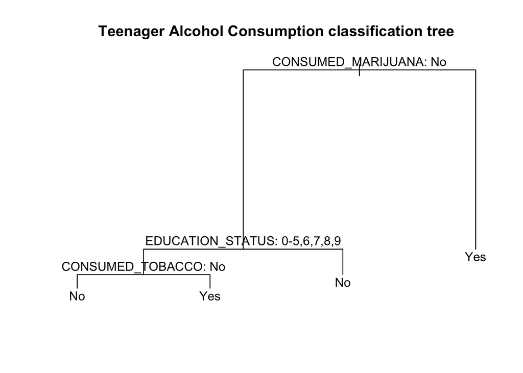

```r
#plot the decision tree
plot(tree.CONSUMED_ALCOHOL)
text(tree.CONSUMED_ALCOHOL, pretty = 0)
title(main = "Teenager Alcohol Consumption classification tree")
```

Tree Interpretation:

The most important variable for predicting whether a teen has ever consumed alcohol or not is CONSUMED_MARIJUANA since the first split criterion starts at the top of the tree. It is subdivided into two branches: if the teen has not consumed marijuana (Left-hand branch) and if the person has consumed marijuana (Right-hand branch).

1. Students who have smoked tobacco and are under the ninth grade are more likely to consume alcohol.
2. Similarly, students who have not smoked tobacco and are under the ninth grade are unlikely to consume alcohol.
3. Teens who have consumed marijuana are likely to consume alcohol.

```r
#Predicting the tree based model
tree.pred <- predict(tree.CONSUMED_ALCOHOL, binary.test,type = "class")

#Confusion matrix
table(tree.pred,binary.test$CONSUMED_ALCOHOL)
```

```
##
## tree.pred   No  Yes
##       No  1264  197
##       Yes   39  151
```

```r
errorrate<- mean(binary.test$CONSUMED_ALCOHOL!=tree.pred)
cat("Test error rate for binary classification is ", errorrate)
```

```
## Test error rate for binary classification is  0.1429437
```

```r
accuracy<- mean(binary.test$CONSUMED_ALCOHOL==tree.pred)
cat("Test accuracy for binary classification is ", accuracy)
```

```
## Test accuracy for binary classification is  0.8570563
```

##### PROBLEM-2

#Create multi-class classification model

```r
#select variables for multiclass classification
df_multiclass <-selected_data %>%
  dplyr::select(CONSUMED_TOBACCO,CONSUMED_MARIJUANA,ALCOHOL_DAYS,HEALTH_STATUS,EDUCATION_STATUS,GENDER,YOUTH_FIGHTS,GOVT_ASSISTANCE,TOTAL_INCOME,METRO_STATUS)
```

```r
#Split the data into train and test by considering 70% of data as training data and reserving the remaining 30% of data as test data
set.seed(1)
train <- sample(nrow(df_multiclass) * 0.7)
multi.train <- df_multiclass[train, ]
multi.test <- df_multiclass[-train, ]
```

#Implement the Bagging model for multi-class classification

```r
npredictors=length(multi.train)
tic()
bag.ALCOHOL_DAYS <- randomForest(ALCOHOL_DAYS ~ ., data = multi.train, mtry = npredictors, importance = TRUE,ntree=100)
bag.ALCOHOL_DAYS
```

```
##
## Call:
##  randomForest(formula = ALCOHOL_DAYS ~ ., data = multi.train,      mtry = npredictors, importance = TRUE, ntree = 100)
##                Type of random forest: classification
##                      Number of trees: 100
## No. of variables tried at each split: 9
##
##         OOB estimate of  error rate: 19.93%
## Confusion matrix:
##            Frequent Never used Seldom Sometimes class.error
## Frequent          2         16     36         2  0.96428571
## Never used        4       2825    196        10  0.06919275
## Seldom           19        394    252        21  0.63265306
## Sometimes         1         28     40         3  0.95833333
```

```r
toc()
```

```
## 1.211 sec elapsed
```

```r
#Predicting the model on test dat
ALCOHOL_DAYS.pred <- predict(bag.ALCOHOL_DAYS, multi.test,type = "class")
Predicted<-ALCOHOL_DAYS.pred
Actual<-multi.test$ALCOHOL_DAYS
#table(multi.test$ALCOHOL_DAYS,ALCOHOL_DAYS.pred)
#mean(multi.test$ALCOHOL_DAYS!=ALCOHOL_DAYS.pred)
table(Actual,Predicted)
```

```
##             Predicted
## Actual       Frequent Never used Seldom Sometimes
##   Frequent          1          4      4         0
##   Never used        3       1299     67         2
##   Seldom            4        154     92         6
##   Sometimes         1          7      7         0
```

```r
errorrate<- mean(Actual!=Predicted)
cat("Test error rate for multi-class classification using bagging is ", errorrate)
```

```
## Test error rate for multi-class classification using bagging is  0.1568746
```

```r
accuracy<-mean(Actual==Predicted)
cat("Test accuracy for multi-class classification using bagging is ", accuracy)
```

```
## Test accuracy for multi-class classification using bagging is  0.8431254
```

#Implement the Random Forest model for multi-class classification

```r
tic()
rf.ALCOHOL_DAYS <- randomForest(ALCOHOL_DAYS ~ ., data = multi.train, mtry = sqrt(npredictors), importance = TRUE,ntree=100)
rf.ALCOHOL_DAYS
```

```
##
## Call:
##  randomForest(formula = ALCOHOL_DAYS ~ ., data = multi.train,      mtry = sqrt(npredictors), importance = TRUE, ntree = 100)
##                Type of random forest: classification
##                      Number of trees: 100
## No. of variables tried at each split: 3
##
##         OOB estimate of  error rate: 17.12%
## Confusion matrix:
##            Frequent Never used Seldom Sometimes class.error
## Frequent          1         14     40         1  0.98214286
## Never used        0       2913    122         0  0.04019769
## Seldom            7        399    274         6  0.60058309
## Sometimes         1         26     43         2  0.97222222
```

```r
toc()
```

```
## 0.837 sec elapsed
```

```r
ALCOHOL_DAYS.pred <- predict(rf.ALCOHOL_DAYS, multi.test,type = "class")
Predicted<-ALCOHOL_DAYS.pred
Actual<-multi.test$ALCOHOL_DAYS
#table(multi.test$ALCOHOL_DAYS,ALCOHOL_DAYS.pred)
#mean(multi.test$ALCOHOL_DAYS!=ALCOHOL_DAYS.pred)
table(Actual,Predicted)
```

```
##             Predicted
## Actual       Frequent Never used Seldom Sometimes
##   Frequent          0          4      5         0
##   Never used        0       1336     35         0
##   Seldom            2        162     92         0
##   Sometimes         0          6      9         0
```

```r
errorrate<- mean(Actual!=Predicted)
cat("Test error rate for multi-class classification using Random Forest is ", errorrate)
```

```
## Test error rate for multi-class classification using Random Forest is  0.1350697
```

```r
accuracy<-mean(Actual==Predicted)
cat("Test accuracy for multi-class classification using Random Forest is ", accuracy)
```

```
## Test accuracy for multi-class classification using Random Forest is  0.8649303
```

It can be seen that the error rate is less for the random forest model compared to the bagging model

```r
#importance of each predictor
importance(rf.ALCOHOL_DAYS)
```

```
##                      Frequent Never used    Seldom   Sometimes
## CONSUMED_TOBACCO    7.1015023 22.3560679  5.966468  5.25481265
## CONSUMED_MARIJUANA  2.2484178 36.6958487 37.340433  4.74749399
## HEALTH_STATUS      -1.1828950 -1.1952916 -1.548785  2.81130112
## EDUCATION_STATUS    3.2530784  3.2057837 10.014426  0.04617373
## GENDER              1.8645644  0.6893594  1.802219  0.65888808
## YOUTH_FIGHTS        1.3415043  5.0025440 -1.378514  2.23467555
## GOVT_ASSISTANCE    -0.4021878  4.8622338  1.094297 -0.65491785
## TOTAL_INCOME       -0.5811371  1.8736101  1.662858  0.41481859
## METRO_STATUS        1.1780432  4.6674951  3.388715  0.56759205
##                    MeanDecreaseAccuracy MeanDecreaseGini
## CONSUMED_TOBACCO              23.453184         86.20886
## CONSUMED_MARIJUANA            46.626524        219.46149
## HEALTH_STATUS                 -1.644983         66.51090
## EDUCATION_STATUS               9.713678        133.45173
## GENDER                         2.076032         31.55570
## YOUTH_FIGHTS                   3.363194         25.10047
## GOVT_ASSISTANCE                5.022550         24.69254
## TOTAL_INCOME                   2.695899         63.55572
## METRO_STATUS                   5.987907         57.39984
```

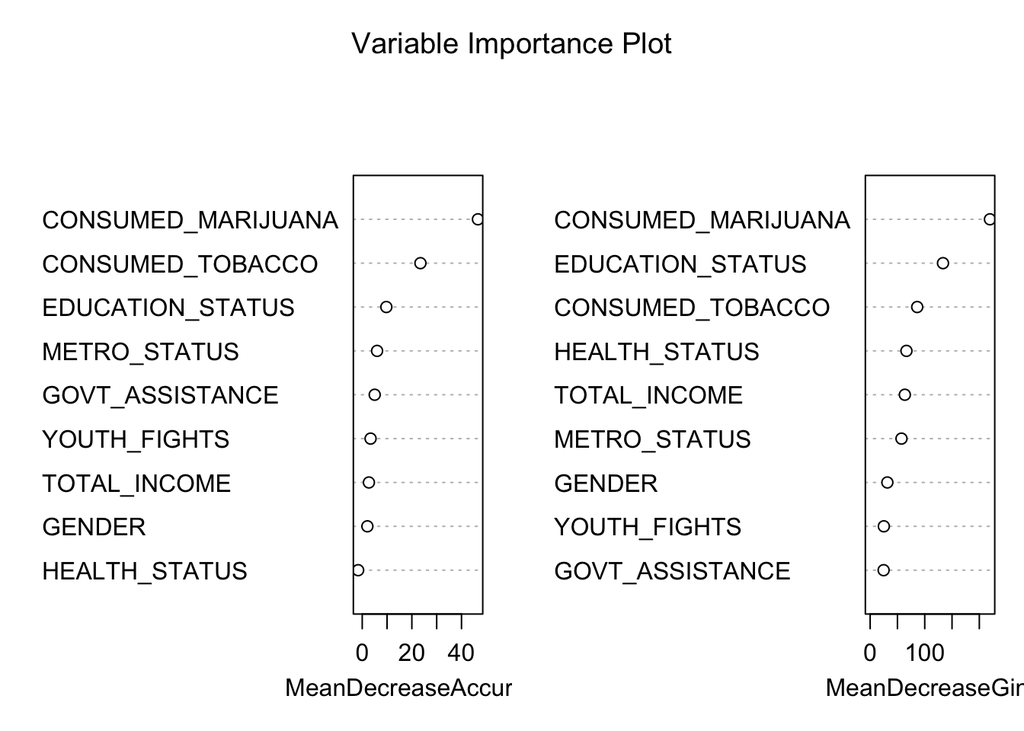

```r
#Plot the importance of each predictor
varImpPlot(rf.ALCOHOL_DAYS, main = "Variable Importance Plot")
```

```r
#Plot the variable importance plot using ggplot for better representation
var_imp_plot <- data.frame(imp_mean_decrease_accuracy = rf.ALCOHOL_DAYS$importance[,"MeanDecreaseAccuracy"],
                         Variables = row.names(rf.ALCOHOL_DAYS$importance))
```

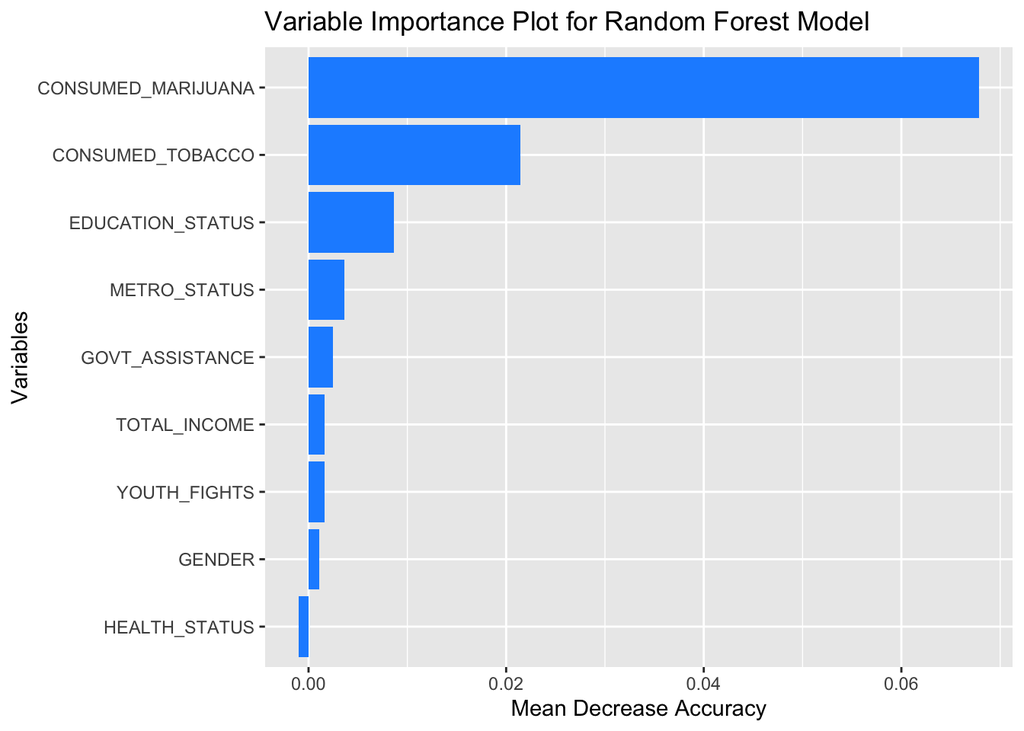

```r
  ggplot(data = var_imp_plot, aes(x = reorder(Variables, imp_mean_decrease_accuracy),
                                y = imp_mean_decrease_accuracy))+
  geom_bar(stat = "identity", fill = "dodgerblue") +
  coord_flip() + xlab("Variables") + ylab("Mean Decrease Accuracy") + ggtitle("Variable Importance Plot for Random Forest Model")
```

- From the plot, it can be observed that CONSUMED_MARIJUANA is the most important variable, followed by CONSUMED_TOBACCO, EDUCATION_STATUS, and METRO_STATUS.

```r
# Plotting the oob error vs number of trees for bagging and random forest models:
ALCOHOL_DAYS.err <- data.frame(
  Trees=1:bag.ALCOHOL_DAYS$ntree,
  Error=c(bag.ALCOHOL_DAYS$err.rate[,"OOB"],rf.ALCOHOL_DAYS$err.rate[,"OOB"]),
  Type=rep(c("Bagging with m=p", "RF with m=sqrt(p)"), each=bag.ALCOHOL_DAYS$ntree)
)
```

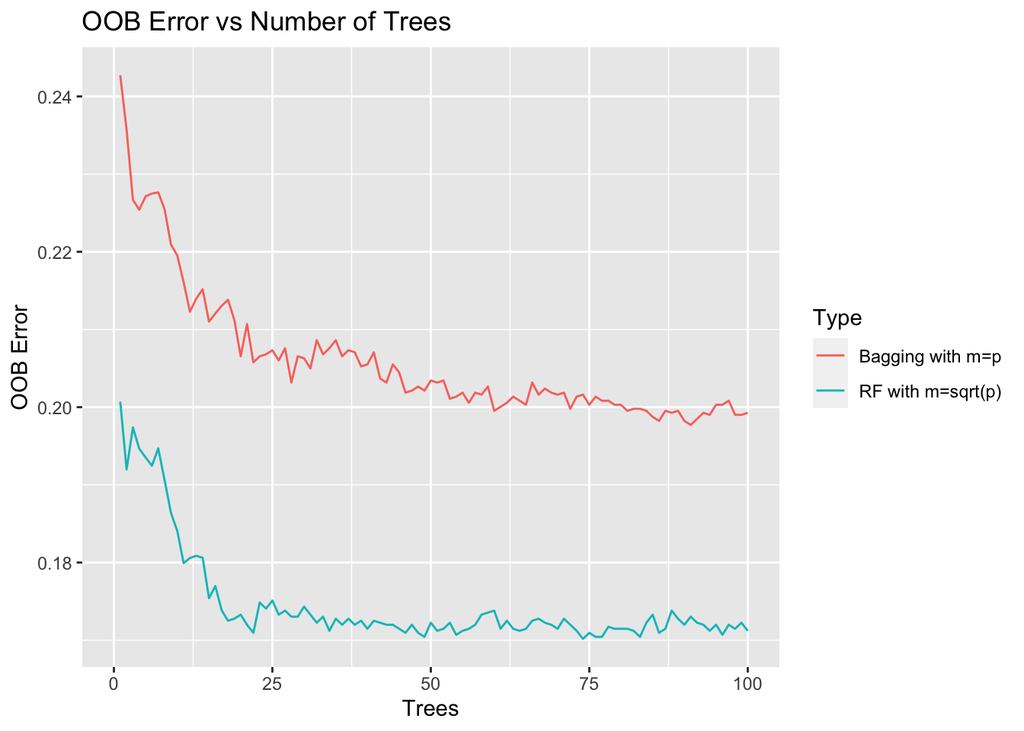

```r
ggplot(data=ALCOHOL_DAYS.err, aes(x=Trees, y=Error)) +  geom_line(aes(color=Type)) + xlab("Trees") + ylab("OOB Error") + ggtitle("OOB Error vs Number of Trees") + xlim(0,100)
```

From the plot, it can be seen that the random forest model has lower OOB error compared to the bagging model.

##### PROBLEM-3

#Regression-Days per year used alcohol

```r
#select variables for regression problem
df_regression <-selected_data %>%
  dplyr::select(ALCOHOL_FREQUENCY,CONSUMED_TOBACCO,CONSUMED_MARIJUANA,HEALTH_STATUS,EDUCATION_STATUS,GENDER,YOUTH_FIGHTS,GOVT_ASSISTANCE,TOTAL_INCOME,METRO_STATUS)
```

```r
#Split the data into train and test by considering 70% of data as training data and reserving the remaining 30% of data as test data
set.seed(1)
train <- sample(nrow(df_regression) * 0.7)
reg.train <- df_regression[train, ]
reg.test <- df_regression[-train, ]
```

#Fit the Boosting for different interaction depths

#When d=1

```r
set.seed(1)
tic()
boost.ALCOHOL_FREQUENCY1 <- gbm(ALCOHOL_FREQUENCY ~ ., data = reg.train,distribution = "gaussian", n.trees=1000, interaction.depth = 1,shrinkage = 0.01, verbose = F)
toc()
```

```
## 0.46 sec elapsed
```

```r
#Compute the training error
ALCOHOL_FREQUENCY.pred1 <- predict(boost.ALCOHOL_FREQUENCY1, newdata = reg.train, n.trees = 1000)
training.err1<- mean((ALCOHOL_FREQUENCY.pred1 - reg.train$ALCOHOL_FREQUENCY)^2)
cat("Training MSE at depth 1 is ", training.err1)
```

```
## Training MSE at depth 1 is  423.8843
```

```r
#Compute the test Error
ALCOHOL_FREQUENCY.pred1 <- predict(boost.ALCOHOL_FREQUENCY1, newdata = reg.test, n.trees = 1000)
test.err1<- mean((ALCOHOL_FREQUENCY.pred1 - reg.test$ALCOHOL_FREQUENCY)^2)
cat("Test MSE at depth 1 is ", test.err1)
```

```
## Test MSE at depth 1 is  120.3084
```

```r
set.seed(1)
tic()
boost.ALCOHOL_FREQUENCY2 <- gbm(ALCOHOL_FREQUENCY ~ ., data = reg.train,distribution = "gaussian", n.trees=1000, interaction.depth = 2,shrinkage = 0.01, verbose = F)
toc()
```

```
## 0.762 sec elapsed
```

```r
#Compute the training error
ALCOHOL_FREQUENCY.pred2 <- predict(boost.ALCOHOL_FREQUENCY2, newdata = reg.train, n.trees = 1000)
training.err2<-mean((ALCOHOL_FREQUENCY.pred2 - reg.train$ALCOHOL_FREQUENCY)^2)
cat("Training MSE at depth 2 is ", training.err2)
```

```
## Training MSE at depth 2 is  409.7657
```

```r
#Compute the test error
ALCOHOL_FREQUENCY.pred2 <- predict(boost.ALCOHOL_FREQUENCY2, newdata = reg.test, n.trees = 1000)
test.err2<- mean((ALCOHOL_FREQUENCY.pred2 - reg.test$ALCOHOL_FREQUENCY)^2)
cat("Test MSE at depth 2 is ", test.err2)
```

```
## Test MSE at depth 2 is  120.3972
```

#When d=3

```r
set.seed(1)
tic()
boost.ALCOHOL_FREQUENCY3 <- gbm(ALCOHOL_FREQUENCY ~ ., data = reg.train,distribution = "gaussian", n.trees=1000, interaction.depth = 3,shrinkage = 0.01, verbose = F)
toc()
```

```
## 1.045 sec elapsed
```

```r
#Training Error
ALCOHOL_FREQUENCY.pred3 <- predict(boost.ALCOHOL_FREQUENCY3, newdata = reg.train, n.trees = 1000)
training.err2<-mean((ALCOHOL_FREQUENCY.pred3 - reg.train$ALCOHOL_FREQUENCY)^2)
cat("Training MSE at depth 2 is ", training.err2)
```

```
## Training MSE at depth 2 is  384.0853
```

```r
#Test Error
ALCOHOL_FREQUENCY.pred3 <- predict(boost.ALCOHOL_FREQUENCY3, newdata = reg.test, n.trees = 1000)
test.err2<- mean((ALCOHOL_FREQUENCY.pred3 - reg.test$ALCOHOL_FREQUENCY)^2)
cat("Test MSE at depth 2 is ", test.err2)
```

```
## Test MSE at depth 2 is  126.8978
```

```r
# Plotting the number of trees vs taining error for all the boosting models

#creat a new dataframe
ALCOHOL_FREQ.err <- data.frame(
  Trees=1:1000,
  Error=c(boost.ALCOHOL_FREQUENCY1$train.error,boost.ALCOHOL_FREQUENCY2$train.error,boost.ALCOHOL_FREQUENCY3$train.error),
  Type=rep(c("BOOSTING with d=1 and s=0.01","BOOSTING with d=2 and s=0.01","BOOSTING with d=3 and s=0.01"),each=1000)
)
```

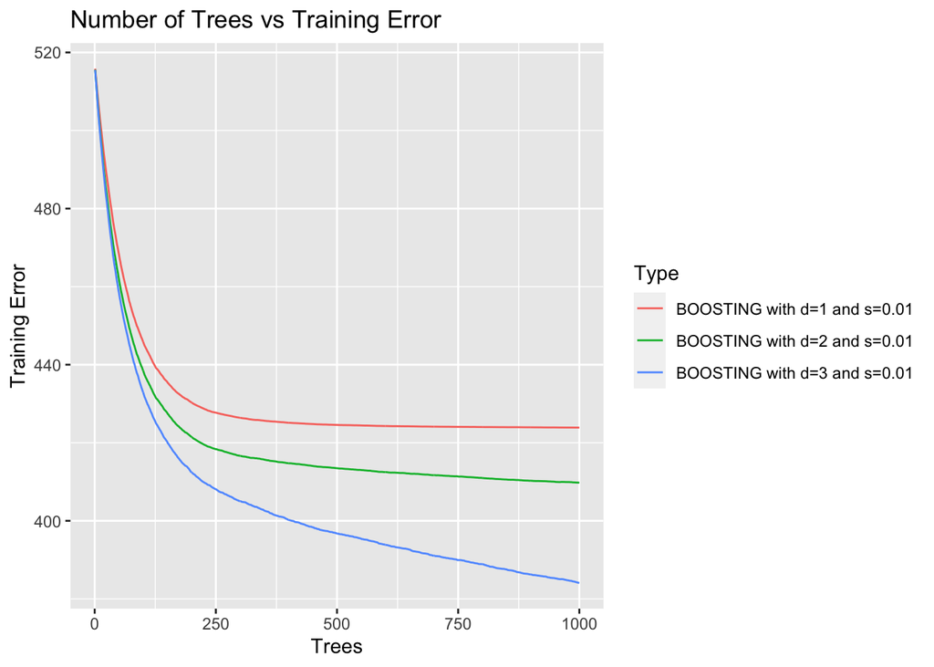

```r
#plot using ggplot
ggplot(data=ALCOHOL_FREQ.err, aes(x=Trees, y=Error)) +  geom_line(aes(color=Type)) + xlab("Trees") + ylab("Training Error") + ggtitle("Number of Trees vs Training Error") + xlim(0,1000)
```

It can be observed that the training error is the least when the gradient boosting model has an interaction depth of 3. The training errors when depth is 1, 2, and 3 are 423, 409, and 384 respectively. Similarly, the mean square error on the test data at interaction depths 1, 2, and 3 are 120.30, 120.39, and 126.89 respectively. Although, on the training data the least mean square error is at depth 3, on the actual test data, the lowest mean square error is observed at depth 1. Therefore, the best model for the test data has an interaction depth of 1 and a shrinkage parameter of 0.01.